# PSYC40940: From A Plot To A Shiny App

## Today: Read, Modify, And Test A Simple App

By the end of this session, you should be able to:

- Explain what a dashboard helps its reader do, and distinguish its UI from its server.
- Trace how an input value reaches an output using matching names and `$`.
- Modify and test a working example so a selector and slider update a histogram.
- Explain the data and controls with brief text inside the app.

**What we will build:** one histogram app with a group selector, a bin-width slider, and useful explanations.

## Our Plan For Sessions 6-10

We will develop a dashboard in stages, using working examples before adapting the ideas to your own data.

| Session | What we will do | What you will build |
| --- | --- | --- |
| 6 | Connect the UI and server; use controls and automatic updates | A histogram with a group selector, slider, and explanatory text |
| 7 | Share selected data across outputs; organise a sidebar layout | Two coordinated plots and a participant count |
| 8 | Build tabs; choose controls; handle empty selections | Two tabs with reliable filters and helpful feedback |
| 9 | Try Plotly; adapt the ideas to your question and dataset | A working two-view prototype with purposeful interaction |
| 10 | Test the report and app from an extracted ZIP; get support | A reproducible portfolio and clear remaining improvements |

We will inspect examples, make small changes, and test what happens. Session 10 focuses on support, not another set of compulsory functions.

## Dashboards Bring Useful Views Of Data Together

A dashboard brings selected plots, indicators, tables, and explanations together around a question or task.

It can help people:

- **Monitor:** what is changing, and where might attention be needed?
- **Compare:** how do groups, places, or periods differ?
- **Explore:** does a pattern hold for a different selection of the data?

Interactive controls let the reader choose a view. A dashboard need not be live or real-time, and more controls do not automatically make it more useful.

## Explore A Dashboard And Tell Us What It Does

In pairs or small groups, choose one link and explore for **3 minutes**. Then we will hear a couple of very brief examples.

**Choose a dashboard:**

- [OECD: Well-being](https://www.oecd.org/en/data/tools/well-being-data-monitor/current-well-being.html)
- [ONS: UK national well-being](https://www.ons.gov.uk/peoplepopulationandcommunity/wellbeing/articles/ukmeasuresofnationalwellbeing/dashboard)
- [UKHSA: Public health](https://ukhsa-dashboard.data.gov.uk/)
- [Our World in Data: Population](https://ourworldindata.org/explorers/population-and-demography)

**Together, let’s discuss:**

1. What does this dashboard show?
2. What can you change, and what happens when you do?

## We Can Build These Interactions In R

[interactive chart not shown]

Change the group and bin width; hover over the bars.

## A Shiny Dashboard Has An Interface And A Server

**User interface (front end):** the controls, plots, tables, layout, and explanations the user sees in the browser.

**Server (back end):** R code that selects data, calculates summaries, and generates the content for those outputs.

**Reactivity connects them:** Shiny tracks which outputs depend on which inputs and updates them when needed.

**UI**  
Choose an output group

→

**Server**  
Filter data / build the plot

→

**UI**  
Display the histogram

The plot’s location belongs to the UI; the code that creates its content belongs to the server.

## Running Commands Vs Defining Dependencies

**R is still the same language.** Shiny adds a reactive programming framework.

| Ordinary R script | Reactive Shiny app |
| --- | --- |
| You run commands in sequence | Define dependencies between inputs and outputs |
| Changing a variable does not automatically update earlier results | Changing input causes affected outputs to recalculate |
| You decide when to rerun the plotting code | Shiny manages when the dependent plotting code runs |

An input change does not restart the app or rerun its entire script.

**Today:** automatic updates inside `renderPlot()`. **Week 7:** use `reactive()` to share preparation across several outputs.

## Download The Week 6 App And Worksheet

Download the Week 6 ZIP from NOW. **Unzip the whole folder into your existing module project.**

```
Your existing module project/
  week-06-shiny-basics-reactivity/
    minimal_app.R
    starter_app.R
    slider_app.R
    01_read_and_modify_a_shiny_app.Rmd
    data/
      participant_reaction_times.csv
```

**Keep the files inside the Week 6 folder. Do not move individual scripts or CSVs elsewhere, or work inside the ZIP.**

## Knit The Guide Before Starting

Open `01_read_and_modify_a_shiny_app.Rmd` and click **Knit**. Keep the HTML guide beside the source files; its contents menu helps you find each section.

| Guide section | Where to make changes or test |
| --- | --- |
| First: run the minimal app together | run `minimal_app.R` |
| The server is a function Shiny calls | inspect `minimal_app.R` |
| Use $ with a data frame | edit and run the Rmd chunks |
| Part 1: connect a selector to a histogram | edit `starter_app.R` |
| Part 2: connect a slider to the histogram | edit `slider_app.R` |

The unfinished chunks are skipped when knitting. Read the HTML; edit the Rmd or named R script, not the HTML.

## Build One App In Two Stages

| First block | Second block |
| --- | --- |
| Run and inspect a minimal app | See how bin width changes a histogram |
| Identify UI, server, and output names | Add a slider using an example |
| Add a selector and connect it to a plot | Explain both controls and test the app |

**Core outcome:** one working histogram app with two purposeful controls and enough text for another person to understand it.

Each stage: **Together: inspect an example**, **Your turn: modify and test**, then **Together: check what happened**. No typing along with live coding.

## A Complete App In A Few Lines

```r
library(shiny)

ui <- fluidPage(
  numericInput("number", "Choose a number", value = 5),
  textOutput("double")
)

server <- function(input, output) {
  output$double <- renderText({
    input$number * 2
  })
}

shinyApp(ui, server)
```

**Together:** guide section **First: run the minimal app together**. Open `minimal_app.R`. Use **Run App**, not Knit, for the app scripts. Locate the UI and server; we will now trace how the app works.

`shinyApp(ui, server)` combines the interface and server to start the app.

## The Server Is A Function Shiny Calls

```r
server <- function(input, output) {
  output$double <- renderText({
    input$number * 2
  })
}
```

- `<-` stores these instructions under the name `server`.
- `function(input, output)` defines the function and its arguments.
- The body inside `{}` defines how to produce the app’s output.

**Shiny calls the server function** when a user opens the app, supplying `input` and `output`.

Functions define instructions. Reactivity manages when dependent output calculations update; a function is not automatically reactive.

## Use `$` To Select A Named Part

Shiny also uses `$` to access named parts of `input` and `output`. These are special Shiny objects, not data frames, but data frames allow us to illustrate what `$` does.

```r
example_data <- data.frame(
  number = 1:5, doubled = (1:5) * 2
)
example_data
```

```
#>   number doubled
#> 1      1       2
#> 2      2       4
#> 3      3       6
#> 4      4       8
#> 5      5      10
```

```r
example_data$doubled
```

```
#> [1]  2  4  6  8 10
```

For a data frame, `$doubled` selects the column named `doubled`.

**Your turn:** guide section **Use $ with a data frame**. Complete the Rmd blank to select the original `number` column, then test it.

## The UI Names An Input And An Output

```r
ui <- fluidPage(
  numericInput(
    inputId = "number",          # Internal input name
    label = "Choose a number",  # Visible label
    value = 5
  ),
  textOutput("double")          # Internal output name
)
```

| Part | Name in the UI | Use in the server |
| --- | --- | --- |
| Input control | `"number"` | `input$number` |
| Output location | `"double"` | `output$double` |

UI elements are separated by commas. The final element has no trailing comma.

## The Server Connects The Input To The Output

```r
server <- function(input, output) {
  output$double <- renderText({  # Output name: double
    input$number * 2            # Input name: number
  })
}
```

`output$double` matches `textOutput("double")` in the UI.

`renderText()` reads `input$number`: change the input and Shiny recalculates the result.

Control changes update the dependent output, not the whole server function.

**Your turn:** predict the result for 7, then test it. **Together: check** trace `number` from `numericInput()` to `input$number`, and `double` from `output$double` to `textOutput()`.

## Start With A Plot You Already Know

The supplied data contain **72 participant means**, not trial-level reaction times. Each mean combines familiarisation conditions.

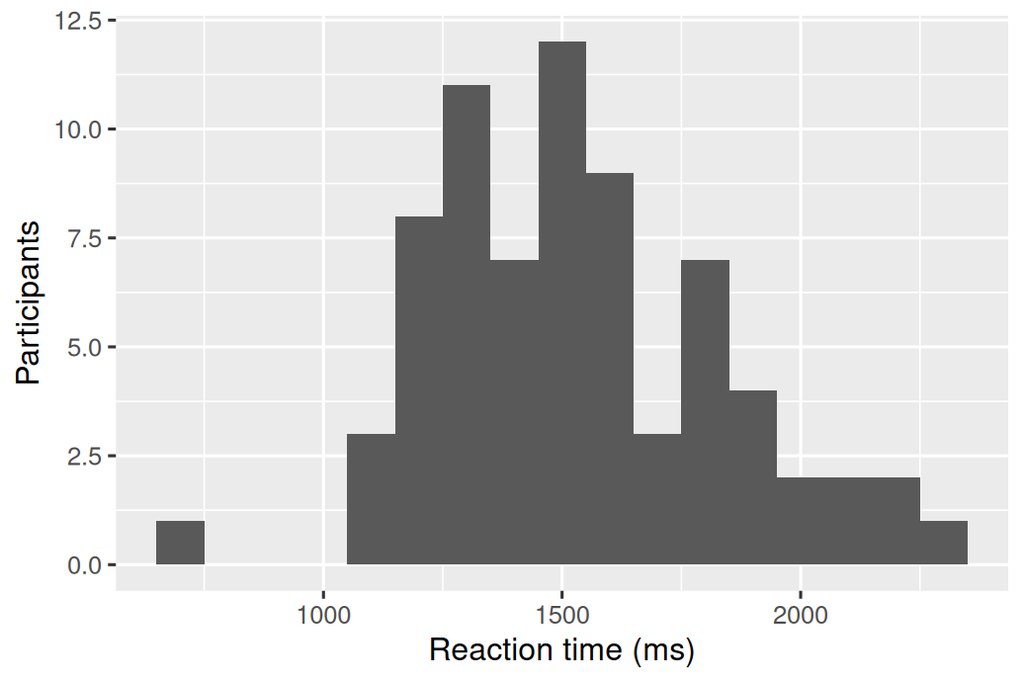

```r
ggplot(d_participants,
       aes(x = mean_rt)) +
  geom_histogram(binwidth = 100) +
  labs(x = "Reaction time (ms)",
       y = "Participants")
```

The Shiny task is to let a reader change which observations appear and how they are grouped.

## The Same Connection Pattern Works For Plots

| Output location in the UI | Content generated in the server |
| --- | --- |
| `textOutput("double")` | `output$double <- renderText(...)` |
| `plotOutput("rt_plot")` | `output$rt_plot <- renderPlot(...)` |

The output type changes, but the names still have to match. The familiar ggplot code goes inside `renderPlot()`.

## Controls Need An Internal Name And A Label

```r
selectInput(
  inputId = "modality",    # Internal input name
  label = "Output group", # Visible label
  choices = c("Spoken output" = "speech",
              "Written output" = "writing")
)
```

- `inputId = "modality"` gives the control its internal name: read its value as `input$modality`.
- The user sees the label and readable choice names.
- Data values are `speech` and `writing`, not the displayed choice names.

Adding the selector alone does not change a plot that never uses its value.

## A Filter Connects The Selector To The Plot

**Together:** `filter()` keeps rows that satisfy a condition, keeping all columns.

```r
output$rt_plot <- renderPlot({
  selected_data <- filter(
    d_participants, modality == input$modality
  )
  ggplot(selected_data, aes(x = mean_rt)) +
    geom_histogram(binwidth = 100)
})
```

`modality` is a data column; `input$modality` is the selected value. `==` tests whether they are equal for each row.

Selecting `"speech"` keeps the 33 spoken-group rows. `<-` stores this subset as `selected_data`; the original data are unchanged.

Changing the selection makes `renderPlot()` recalculate. No `reactive()` function is needed yet.

## Exercise 1: Add A Group Selector

Open `starter_app.R`; use **Part 1** of the Rmd instructions (about 15 minutes).

- Complete the UI output name, the filter’s input name, and the plotting dataset.
- After editing code: save, stop the app, and run again.
- Change the group: does the histogram update?

**When testing controls:** keep the app running.

The structure and selector are supplied. Use the connection examples on the slides to complete the blanks.

**Your turn:** make and test the three connections using the example.

**Together: check** which line makes the group selection affect the plot, and why the output names must match.

## Mismatched Names Can Disconnect An Output

| UI | Server | Result |
| --- | --- | --- |
| `plotOutput("rt_plot")` | `output$rt_plot` | matching plot connection |
| `plotOutput("reaction_plot")` | `output$rt_plot` | no matching plot location |

**Together:** predict what happens when only the UI name changes. Check how matching the two names repairs the connection.

Also check the Console for errors, commas between UI elements, and closing brackets. Test one change at a time.

## Bin Width Changes The Summary

**Bins** are intervals on the x-axis; each bar counts the participants whose values fall within that interval. **Bin width** is the interval’s size, here in milliseconds.

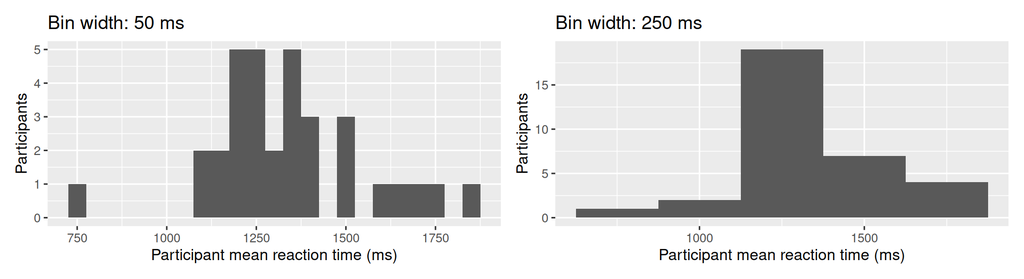

- **What persists:** most values cluster around 1,200–1,400 ms in both plots.
- **What changes:** narrow bins show small peaks and gaps; wider bins merge them and can hide detail.
- **Why a slider?** Readers can check whether a pattern holds across widths. The same 33 participants and their values stay fixed.

## A Slider Can Control A Plot Parameter

Add the control to the UI:

```r
sliderInput("binwidth",         # Internal input name
            "Bin width (ms)",  # Visible label
            min = 25, max = 300, value = 100, step = 25)
```

Use its name inside `renderPlot()`:

```r
geom_histogram(binwidth = input$binwidth)
```

Here, the selected value is a number. It replaces a fixed number in familiar ggplot code.

## Different Controls Answer Different Questions

| Control | What changes? | What stays fixed? |
| --- | --- | --- |
| Output group | which participants are included | meaning of reaction time |
| Bin width | how reaction times are grouped | selected participants and their values |

`input$modality` and `input$binwidth` are both read inside the plot’s render function. A change to either causes the plot to update.

## Explanatory Text Belongs In The App

```r
# Describe what each observation represents.
p("Each value represents one participant's mean
   reaction time across familiarisation conditions.")

helpText("Only participants in the selected output
          group are included in the histogram.")
```

A useful explanation identifies the data, units, selection, and limits of interpretation.

A comment beginning with `#` is for the programmer. The app user cannot see it.

## Exercise 2: Add A Slider And Explain Its Effect

Open `slider_app.R`; use **Part 2** of the Rmd instructions (about 25 minutes).

- Complete the slider label, starting value, input connection, and two text blanks.
- Find where `p()` and `helpText()` appear, then write useful data and control explanations.
- After editing code: save, stop the app, and run again.
- Hold the group fixed while trying several widths.
- Compare your help text with a neighbour’s: what changes with bin width, and what stays the same? Revise one sentence if needed.

**When testing controls:** keep the app running.

Keep text accurate and brief. Explain what each control changes, not just what it is called.

**Your turn:** complete and test the app; use the slider example as a model.

**Check** why does changing bin width not change the participant count. Compare your help texts.

## Next Week: Several Views Of The Same Selection

Today: controls update one plot through `renderPlot()`.

Next week: add another plot and a summary, with shared preparation using `reactive()`.

Later: layout, sensible input handling, Plotly, and adapting an app to your own data. Advanced generated UI is optional, not a requirement for a useful dashboard.

## Start Exploring Possible Summative Datasets

Start looking for data on a topic that interests you for the summative assessment.

- Browse the available variables and what each observation represents.
- Keep the source link for anything that looks promising.
- We will discuss dataset suitability and app ideas in later weeks.

**It is fine not to have a dataset yet.** No dataset choice or dashboard plan is required at this stage.

## After Class: Read About Your First Shiny App

**Everyone:** read Wickham (2021), [Chapter 1: Your first Shiny app](https://mastering-shiny.org/basic-app.html), **sections 1.1-1.5**, ending with *Adding behaviour*.

As you read, connect the example to today’s app:

- Which parts belong to the UI and which to the server?
- Where do the input and output names connect?
- Why does changing an input update an output?

No written submission or book exercises are required. Section 1.6 introduces shared reactive expressions: optional preparation for next week.

**Optional reference:** [Shiny helpText documentation](https://shiny.posit.co/r/reference/shiny/latest/helptext.html).

## Add Text That Updates

**Independent work, or if there is time in class.** Use the guide section **Optional: add a dynamic summary**.

**Goal:** display the selected participant count and bin width above your histogram. Unlike `helpText()`, this text updates when a control changes.

1. Run `extension_app.R` and test its summary, then stop it.
2. In your `slider_app.R`, add `textOutput("selection_note")` before `plotOutput()` in the UI.
3. Copy `output$selection_note <- renderText({ ... })` block into the server, alongside the plot block. The guide shows exactly where both parts belong.

Inside `renderText()`, `filter()` selects the group, `nrow()` counts its participants, and `paste()` joins the values into a sentence.

**Check:** switching from spoken to written output changes the count from **33 to 39**. Changing bin width updates the displayed width, while the count stays fixed.

**Further change:** include the selected group in the summary using `input$modality`.

## After Completing Your App: Compare And Explain

You can now open `worked_example_app.R`, the completed reference for the two controls and explanatory text.

- Run it and compare its behaviour with your own app.
- Trace each control from its UI name to its use in the server.
- If something differs, identify the relevant connection and explain the change needed in your own code.
- Compare the explanations: does your text help someone understand the data and controls?

Keep your own version. Use the reference to check your reasoning and revisit the code after class.

## References

Wickham, H. (2021). *Mastering shiny*. O’Reilly Media.